# Wild Impact Tracker presentation

## Wild Impact Tracker presentation

### What this tracker is

The tracker is used as a recording system for estmating travel-related emissions and avoided emissions across Wild Impact landscapes.

[output not shown]

> **Vehicles** and **Boats** are reserved for future versions of the tracker; the current operational calculations are flights and e-bikes.

### Why build a dedicated tracker?

- The main reason is because: **I Dislike Excel**
- Consistancy in record-keeping across all projects and landscapes rather than relying on multiple spreadsheets.
- Easier to use when complex emission tracking and calculations are introduced. e.g. Flights, Vehicles, Boats, etc.
- Saves everyone involved the time and effort of calculating carbon emissions manually or on excel in an untidy manner.

[figure not shown]

### Scope, boundaries and what the numbers mean

| Currently included | Not yet included | Interpretation |
| --- | --- | --- |
| - Flight CO<sub>2</sub>estimates | - Non-CO<sub>2</sub> aviation effects (contrails and NO<sub>2</sub>) | These are model-based estimates |
| - Aircraft fuel consumption | - Vehicles and Boats modules | No direct measurement of fuel burned on a specific flight was used |
| - Passenger/load allocation | - A full life-cycle assessment of e-bikes or motocycles | No direct measurement of fuel burned on boda-boda bikes was used |
| - Cabin factor |  |  |
| - E-Bike charging emissions |  |  |
| - E-Bike estimated avoided emissions |  |  |

### How a user works with the tracker

#### Step 1: Choose a module

There are currently two modules open as of this version – Aircrafts and E-Bikes. More modules will be open in the near future.

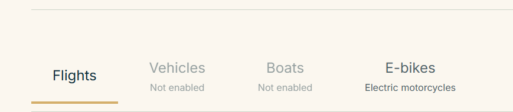

#### Step 2: Enter activity

All modules have one thing similar: You will always be required to enter the date, person involved, and the landscape the person is from.

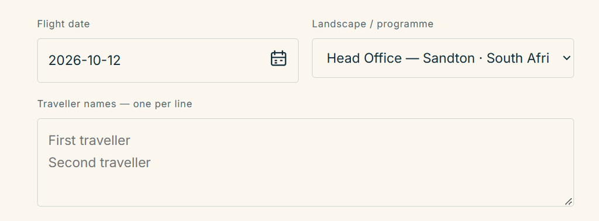

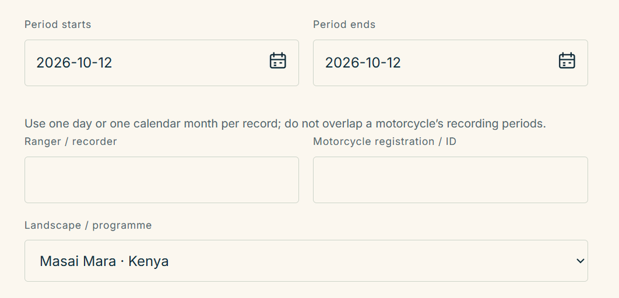

#### Step 3: Select references

When entered on the Aircrafts module, you will be required to select whether flights booked are domestic or international, airports of departure and arrival, airlines used, etc. When in the E-Bikes module, you will be required to enter registration numbers, distance travelled, mode used to charge E-bikes.

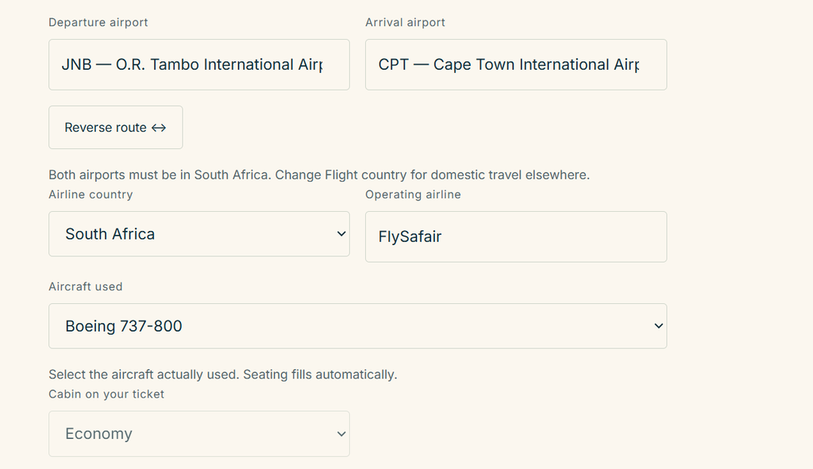

#### Step 4: Calculate

The model calculates emissions in the background using json files and records the steps on the tracker itself.

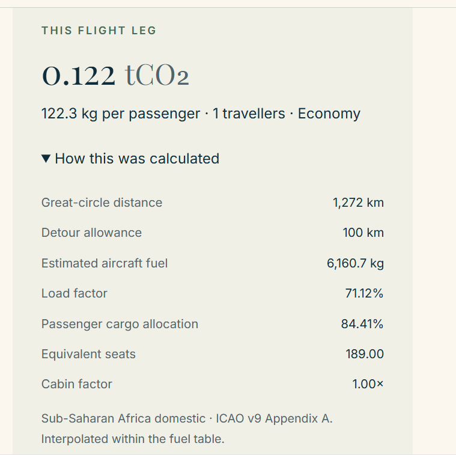

#### Step 5: Save Records

All records are saved the user's local browser and **NOT MADE PUBLIC** to anyone else.

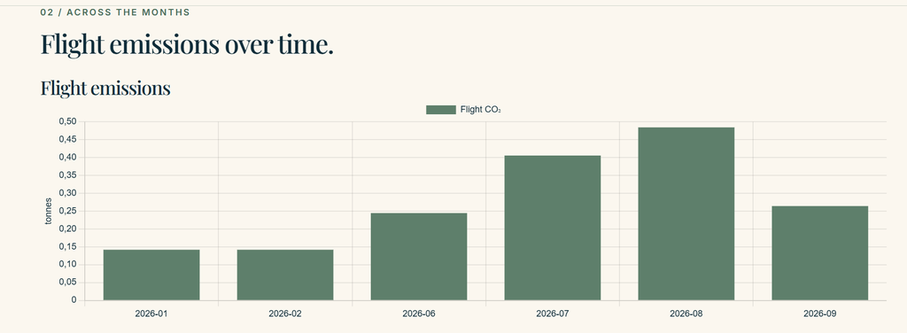

#### Step 6: Report/Sync

The idea is to get an Excel workbook as the final output. Recording on the tracker should lead to an excel spreadsheet with all formaulas and records written down because Wild Impact uses excel to store databases.

[figure not shown]

### Summary of data input behind the calculations

The tracker bundles local JSON files; the browser reads these to populate choices and run the model.

`airport-reference.json` — Contains 10 533 airport records globally. `aircraft-reference.json` — Contains 86 different aircraft types and their specs. `airline-reference.json` — Contains 83 airline/operators, globally. Most are in South Africa. `flight-configurations.json` — 29 published layout profiles of aircraft cabin counts, seat-space factors, etc. `icao fuel curves` — Contains fuel consumption curves from ICAO v9 (2014) and v13.1 (2024). `landscape-refrence.json` — 14 landscapes of Wild Impact and their countries.

### Flight calculations: from route to CO<sub>2</sub>

#### 1: Distance calculator

The distance has no standard formula used to calculate. It is just the Great-Circle Distance. Distance from one airport to the other using the curvature of the earth.

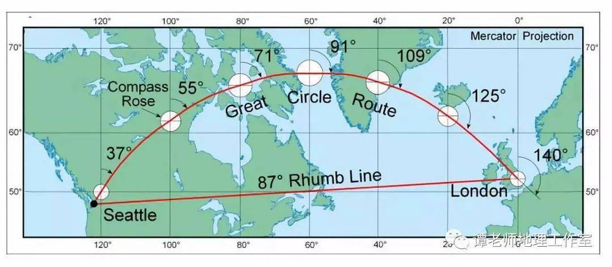

#### 2: Route detour allowance

Because there are other factors we cannot control during flights (Stacking, traffic, re-landing, detours), we have to account for those factors using the GCD correction. Below are the values used as Correction to GCD:

| Great-Circle Distance | Correction to Great-Circle Distance |
| --- | --- |
| Less than 550 km | + 50 km |
| Between 550 km and 5500 km | + 100 km |
| Above 5500 km | + 125 km |

#### 3: Fuel consumption

To get fuel consumption from ICAO data, I used Linear interpolation. Linear Interpolation is explained/demonstrated below:

Open: https://icec.icao.int/Documents/Methodology%20ICAO%20Carbon%20Emissions%20Calculator_v13_Final.pdf

**Calculate interpolation fraction**

Lower point: x<sub>1</sub> = 250 nm, with y<sub>1</sub> = 2703 kg

Upper point: x<sub>2</sub> = 500 nm, with y<sub>2</sub> = 3788 kg

Required Distance: x = 300 nm

> This means that flight distance is 20% of the way from lower point to upper point.

**Calculate difference in fuel consumption**

We basically asking: How much more fuel is the aircraft estimated to use at upper distance than lower distance

$\Delta$F = F<sub>2</sub> — F<sub>1</sub> = 3788 — 2703 = 1085

> This means that there was a 1085 kg increase across the 250 nm interval.

**Estimate the additional fuel**

Because the required distance is 20% of the way throug interval, we take 20% of the fuel difference

Additional fuel = Fraction x $\Delta$F = 0.2 x 1085 kg = 217 kg

**Calculate estimated fuel consumption**

We now add fuel to the lower reference value

F(x) = F<sub>1</sub> + Additional fuel = 2703 + 217 = 2920

**Complete interpolation formula**

where F(x) = estimated fuel consumption at required distance x = Required flight distance x<sub>1</sub> and x<sub>2</sub> = lower and upper refrence distance F<sub>1</sub> and F<sub>2</sub> = fuel values of these reference points

#### 4: Allocation + Cabin

How much of the carbon calculated is allocated to people on board?

To get CO<sub>2</sub> per passenger:

kg CO<sub>2</sub> per passenger = $\frac{Fuel x 3.16 x Cargo allocation}{Seats x passenger load factor}$ x Cabin allocation

where 3.16 is a constant for number of tonnes CO<sub>2</sub> produced by burning a tonne of aviation fuel. Basically used to convert kg to CO<sub>2</sub>.

#### 5: Total

Now we calculate the CO<sub>2</sub> based on individuals on the plane.

The formula is:

Flight total CO<sub>2</sub> = kg CO<sub>2</sub> per passenger x passenger count

The tracker will automatically convert the results to tonnes by dividing by 1000.

### How will this system work?

The whole system will be hosted online on netlify and GitHub under private repositories to prevent external sources from accessing the files. The tracker will be hosted to netlify for online use. *Only users with the link will be able to access and use the tracker.*

How this system works:

Users enter data on the site and the data gets saved automatically | | All data is saved on json files hosted on netlify | | Netlify will have a function that acts as a server side bridge | | The Netlify function reads a PowerAutomate trigger that will read json files from netlify and forward them to power automate | | Powerautomate sends data to Wild Impact sharepoint (The Excel file)

> Have not started PowerAutomate

Thank You!

[figure not shown]